# For_portfolio_credit_fraud

## Credit Card Fraud Detection - Kaggle Data

### Importing necessary libraries

```python
import numpy as np
import pandas as pd

import matplotlib.pyplot as plt
import seaborn as sns
import plotly.express as px
from pylab import rcParams

# Classifier Libraries
import sklearn
from sklearn.linear_model import LogisticRegression
from sklearn.svm import SVC
from sklearn.neighbors import KNeighborsClassifier
from sklearn.model_selection import RandomizedSearchCV

# Libraries for imbalanced data
from imblearn.under_sampling import NearMiss
from imblearn.over_sampling import SMOTE
from imblearn.pipeline import make_pipeline as imb_make_pipeline

# Libraries for metrics
from sklearn.model_selection import cross_val_score
from sklearn.metrics import precision_score, recall_score, f1_score, roc_auc_score
from sklearn.metrics import accuracy_score, classification_report, confusion_matrix

# Other Libraries
from sklearn.model_selection import StratifiedKFold, train_test_split
from sklearn.preprocessing import RobustScaler
from sklearn.pipeline import make_pipeline
from collections import Counter

# For ignoring the warnings
import warnings
warnings.filterwarnings("ignore")
```

```python
# plt.style.use('fivethirtyeight')
%matplotlib inline
rcParams['figure.figsize'] = 15,6
sns.set_style('whitegrid')
```

### Importing and Analyzing Data

The dataset contains transactions made by credit cards in September 2013 by European cardholders. The dataset is highly unbalanced, the positive class (frauds) account for 0.172% of all transactions. It contains only numerical input variables which are the result of a PCA transformation. Unfortunately, due to confidentiality issues, we cannot provide the original features and more background information about the data. Features V1, V2, … V28 are the principal components obtained with PCA, the only features which have not been transformed with PCA are 'Time' and 'Amount'. Feature 'Time' contains the seconds elapsed between each transaction and the first transaction in the dataset. The feature 'Amount' is the transaction Amount, this feature can be used for example-dependant cost-sensitive learning. Feature 'Class' is the response variable and it takes value 1 in case of fraud and 0 otherwise.

```python
df = pd.read_csv('./Data/creditcard.csv')
df.head()
```

|  | Time | V1 | V2 | V3 | V4 | V5 | V6 | V7 | V8 | V9 | ... | V21 | V22 | V23 | V24 | V25 | V26 | V27 | V28 | Amount | Class |
| --- | --- | --- | --- | --- | --- | --- | --- | --- | --- | --- | --- | --- | --- | --- | --- | --- | --- | --- | --- | --- | --- |
| 0 | 0.0 | -1.359807 | -0.072781 | 2.536347 | 1.378155 | -0.338321 | 0.462388 | 0.239599 | 0.098698 | 0.363787 | ... | -0.018307 | 0.277838 | -0.110474 | 0.066928 | 0.128539 | -0.189115 | 0.133558 | -0.021053 | 149.62 | 0 |
| 1 | 0.0 | 1.191857 | 0.266151 | 0.166480 | 0.448154 | 0.060018 | -0.082361 | -0.078803 | 0.085102 | -0.255425 | ... | -0.225775 | -0.638672 | 0.101288 | -0.339846 | 0.167170 | 0.125895 | -0.008983 | 0.014724 | 2.69 | 0 |
| 2 | 1.0 | -1.358354 | -1.340163 | 1.773209 | 0.379780 | -0.503198 | 1.800499 | 0.791461 | 0.247676 | -1.514654 | ... | 0.247998 | 0.771679 | 0.909412 | -0.689281 | -0.327642 | -0.139097 | -0.055353 | -0.059752 | 378.66 | 0 |
| 3 | 1.0 | -0.966272 | -0.185226 | 1.792993 | -0.863291 | -0.010309 | 1.247203 | 0.237609 | 0.377436 | -1.387024 | ... | -0.108300 | 0.005274 | -0.190321 | -1.175575 | 0.647376 | -0.221929 | 0.062723 | 0.061458 | 123.50 | 0 |
| 4 | 2.0 | -1.158233 | 0.877737 | 1.548718 | 0.403034 | -0.407193 | 0.095921 | 0.592941 | -0.270533 | 0.817739 | ... | -0.009431 | 0.798278 | -0.137458 | 0.141267 | -0.206010 | 0.502292 | 0.219422 | 0.215153 | 69.99 | 0 |

5 rows × 31 columns

```python
df.info()
```

```
<class 'pandas.core.frame.DataFrame'>
RangeIndex: 284807 entries, 0 to 284806
Data columns (total 31 columns):
 #   Column  Non-Null Count   Dtype
---  ------  --------------   -----
 0   Time    284807 non-null  float64
 1   V1      284807 non-null  float64
 2   V2      284807 non-null  float64
 3   V3      284807 non-null  float64
 4   V4      284807 non-null  float64
 5   V5      284807 non-null  float64
 6   V6      284807 non-null  float64
 7   V7      284807 non-null  float64
 8   V8      284807 non-null  float64
 9   V9      284807 non-null  float64
```

[output cut: 23 more lines]

As we can see, the data set has no null value.

Now lets check the 'Class' variable. In other words, lets check how balanced our data is.

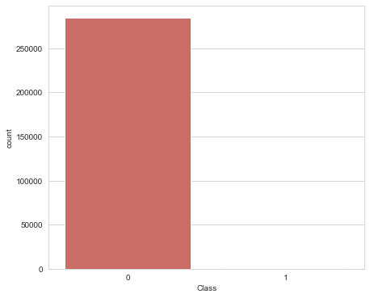

```python
plt.figure(figsize = (7, 6))
sns.countplot(x = 'Class', data = df, palette = 'hls')
```

```python
print('No Fraud entries :', round(df['Class'].value_counts()[0]/len(df) * 100,4), '% of the dataset')
print('Fraud entries :', round(df['Class'].value_counts()[1]/len(df) * 100,4), '% of the dataset')
```

```
No Fraud entries : 99.8273 % of the dataset
Fraud entries : 0.1727 % of the dataset
```

We can see from the plot and the numeric analysis that the data set is highly imbalanced.

Now, lets plot the distribution of the two unscaled features, Amaount and Time. By seeing the distributions we can have an idea how skewed are these features. To better understand the variable's distribution, we will use a log scale.

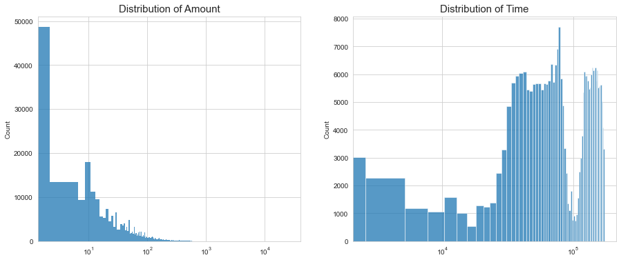

```python
amount_val = df['Amount'].values
time_val = df['Time'].values

fig, ax = plt.subplots(1,2)

sns.histplot(x = amount_val, ax= ax[0]).set(xscale = 'log')
ax[0].set_title('Distribution of Amount', fontsize = 15)

sns.histplot(x = time_val, ax = ax[1]).set(xscale = 'log')
ax[1].set_title('Distribution of Time', fontsize = 15)
```

As we can see the distribution of variable 'Amaount' is highly right skewed and the distribution of variable 'Time' has multiple bump which represents a multimodal logarithmic distribution. This could mean that the transaction time can be divided into multiple groups or sub population. These distributions also tell us that there are some outliers present in the data. We may consider removing these outliers.

Lets check the boxplots of these two features

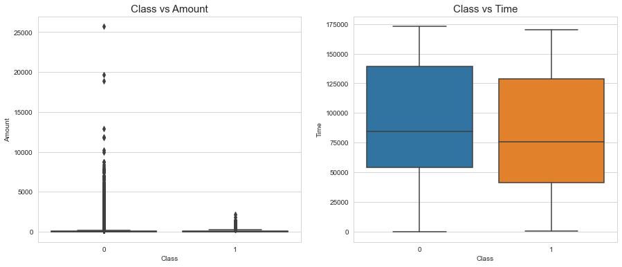

```python
fig, ax = plt.subplots(1,2)

sns.boxplot(x = 'Class', y = 'Amount', ax = ax[0], data = df)
ax[0].set_title('Class vs Amount', fontsize = 15)

sns.boxplot(x = 'Class', y = 'Time', ax = ax[1], data = df)
ax[1].set_title('Class vs Time', fontsize = 15)
```

As predicted, the Amount variable has lots of outliers. However, the transaction time variable doesnt have any outliers and the distribution of time variable for 'Fraud' and 'Non Fraud' transactions are almost similar

#### Corelatoin

Understanding the correlation between the features is also important. It reveals if certain features have more influence over the target variable. We will plot a heatmap to understand the correlation between the features. But before that we will standardize the Amount and Time variable to maintain the consistancy.

```python
robust_scaler = RobustScaler()

scaled_amount = robust_scaler.fit_transform(df['Amount'].values.reshape(-1,1))
scaled_time = robust_scaler.fit_transform(df['Time'].values.reshape(-1,1))
df.drop(['Time', 'Amount'], axis = 1, inplace = True)

df.insert(0, 'scaled_amount', scaled_amount)
df.insert(1, 'scaled_time', scaled_time)

df.head()
```

|  | scaled_amount | scaled_time | V1 | V2 | V3 | V4 | V5 | V6 | V7 | V8 | ... | V20 | V21 | V22 | V23 | V24 | V25 | V26 | V27 | V28 | Class |
| --- | --- | --- | --- | --- | --- | --- | --- | --- | --- | --- | --- | --- | --- | --- | --- | --- | --- | --- | --- | --- | --- |
| 0 | 1.783274 | -0.994983 | -1.359807 | -0.072781 | 2.536347 | 1.378155 | -0.338321 | 0.462388 | 0.239599 | 0.098698 | ... | 0.251412 | -0.018307 | 0.277838 | -0.110474 | 0.066928 | 0.128539 | -0.189115 | 0.133558 | -0.021053 | 0 |
| 1 | -0.269825 | -0.994983 | 1.191857 | 0.266151 | 0.166480 | 0.448154 | 0.060018 | -0.082361 | -0.078803 | 0.085102 | ... | -0.069083 | -0.225775 | -0.638672 | 0.101288 | -0.339846 | 0.167170 | 0.125895 | -0.008983 | 0.014724 | 0 |
| 2 | 4.983721 | -0.994972 | -1.358354 | -1.340163 | 1.773209 | 0.379780 | -0.503198 | 1.800499 | 0.791461 | 0.247676 | ... | 0.524980 | 0.247998 | 0.771679 | 0.909412 | -0.689281 | -0.327642 | -0.139097 | -0.055353 | -0.059752 | 0 |
| 3 | 1.418291 | -0.994972 | -0.966272 | -0.185226 | 1.792993 | -0.863291 | -0.010309 | 1.247203 | 0.237609 | 0.377436 | ... | -0.208038 | -0.108300 | 0.005274 | -0.190321 | -1.175575 | 0.647376 | -0.221929 | 0.062723 | 0.061458 | 0 |
| 4 | 0.670579 | -0.994960 | -1.158233 | 0.877737 | 1.548718 | 0.403034 | -0.407193 | 0.095921 | 0.592941 | -0.270533 | ... | 0.408542 | -0.009431 | 0.798278 | -0.137458 | 0.141267 | -0.206010 | 0.502292 | 0.219422 | 0.215153 | 0 |

5 rows × 31 columns

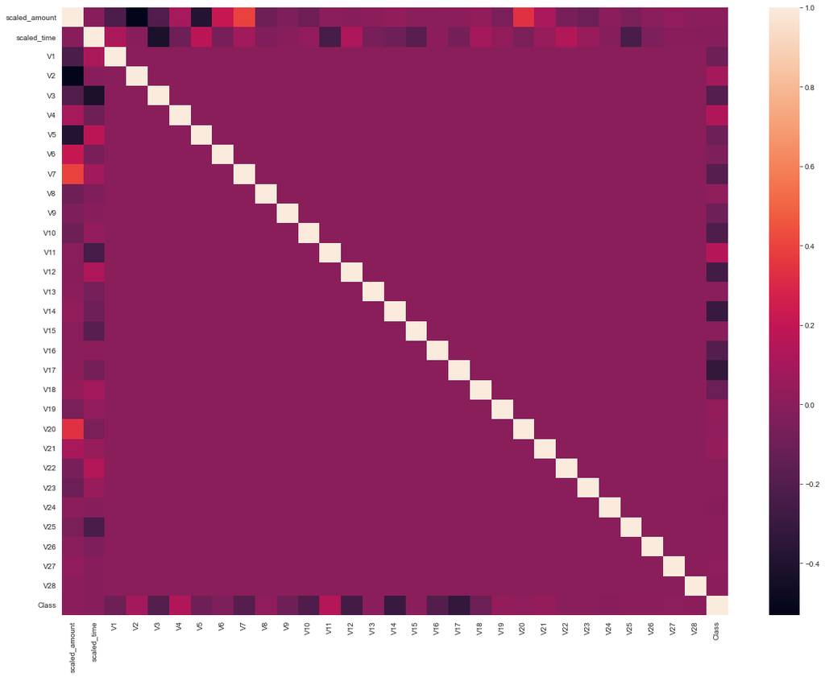

```python
plt.figure(figsize=(20,15))
sns.heatmap(df.corr())
plt.show()
```

We can see here, the Time and Amount features have some colinearity with some of the anonymus features. However, since the features have already been transformed using PCA (for privacy purpose), we dont know much information about them and therefore, we can not just drop any of them. If we drop any, we will lose valuable information.

### Finding Outliers

```python
def outlier_counter(df):
    for col in df.columns[:-1]:
        q75 = df[col].quantile(0.75)
        q25 = df[col].quantile(0.25)
        IQR =  q75 - q25
        threshold = IQR * 1.5
        lower_thres = q25 - threshold
        upper_thres = q75 + threshold
        outliers = [x for x in df[col] if x < lower_thres or x > upper_thres]
        if len(outliers) > 10:
            print(col, 'variable contains ', len(outliers), 'outliers')
        else:
            print(col, 'doesnt have any outliers')
```

```python
outlier_counter(df)
```

```
scaled_amount variable contains  31904 outliers
scaled_time doesnt have any outliers
V1 variable contains  7062 outliers
V2 variable contains  13526 outliers
V3 variable contains  3363 outliers
V4 variable contains  11148 outliers
V5 variable contains  12295 outliers
V6 variable contains  22965 outliers
V7 variable contains  8948 outliers
V8 variable contains  24134 outliers
V9 variable contains  8283 outliers
V10 variable contains  9496 outliers
V11 variable contains  780 outliers
V12 variable contains  15348 outliers
V13 variable contains  3368 outliers
V14 variable contains  14149 outliers
V15 variable contains  2894 outliers
V16 variable contains  8184 outliers
V17 variable contains  7420 outliers
V18 variable contains  7533 outliers
V19 variable contains  10205 outliers
V20 variable contains  27770 outliers
V21 variable contains  14497 outliers
V22 variable contains  1317 outliers
V23 variable contains  18541 outliers
V24 variable contains  4774 outliers
V25 variable contains  5367 outliers
V26 variable contains  5596 outliers
V27 variable contains  39163 outliers
V28 variable contains  30342 outliers
```

Here I considered any datapoint smaller than (25th percentile - 1.5*IQR) or greater than (75th percentile + 1.5*IQR) as outlier. However, since we dont have enough information about the features, it wouldn't be wise to remove those outliers.

### Splitting the data in training and testing dataset

```python
X = df.drop('Class', axis = 1)
y = df['Class']
```

```python
X_train, X_test, y_train, y_test = train_test_split(X, y, test_size = 0.30, shuffle = True, random_state = 26)
```

```python
print('Shape of X_train', X_train.shape)
print('Shape of y_train', y_train.shape)
print('Shape of X_test', X_test.shape)
print('Shape of y_test', y_test.shape)
```

```
Shape of X_train (199364, 30)
Shape of y_train (199364,)
Shape of X_test (85443, 30)
Shape of y_test (85443,)
```

```python
print('No fraud : ', '{:.3f}'.format((y_train.value_counts()[0]/len(y_train))*100), '%')
print('Fraud : ', '{:.3f}'.format((y_train.value_counts()[1]/len(y_train))*100), '%')
```

```
No fraud :  99.829 %
Fraud :  0.171 %
```

Since the data is highly imbalanced, any ML model would be highly biased towards the majority class. We should train ML models with a balanced data for highly accurate unbiased prediction.

Here I will use both undersampling and oversampling to train the model and compare the accuracies.

One thing should be kept in mind that the undersampled or oversampled data should never be used as testing data. It is also important to perform oversampling or undersampling during the cross validation, not before.

### Testing models

At first lets try a few models on the undersampled data to check which model works best for this case.

Since the model trained with imbalanced data will be biased, I will use an undersampled data to perform the initial testing

```python
# Creating an undersampled data

perf_X, perf_y = NearMiss().fit_resample(X.values, y.values)

print('Unique Class values for the undersampled data : ', Counter(perf_y))
```

```
Unique Class values for the undersampled data :  Counter({0: 492, 1: 492})
```

```python
# Splitting the undersampled data into train test datasets

perf_X_train, perf_X_test, perf_y_train, perf_y_test = train_test_split(perf_X, perf_y, test_size = 0.30, shuffle = True, random_state = 26)

print('Shape of perf_X_train', perf_X_train.shape)
print('Shape of perf_y_train', perf_y_train.shape)
print('Shape of perf_X_test', perf_X_test.shape)
print('Shape of perf_y_test', perf_y_test.shape)

print('\n', Counter(perf_y_test))
```

```
Shape of perf_X_train (688, 30)
Shape of perf_y_train (688,)
Shape of perf_X_test (296, 30)
Shape of perf_y_test (296,)

 Counter({0: 156, 1: 140})
```

```python
models = {
    'LogisticsRegression': LogisticRegression(),
    'Support Vector Classifier': SVC(),
    'K Neighbors Classifier' : KNeighborsClassifier()
}

for name, model in models.items():
    model.fit(perf_X_train, perf_y_train)
    training_score = cross_val_score(model, perf_X_train, perf_y_train, cv = 5)
    print(('Classifier : {} has Accuracy : {}').format(name, round(training_score.mean()*100, 3)), '%')
```

```
Classifier : LogisticsRegression has Accuracy : 94.477 %
Classifier : Support Vector Classifier has Accuracy : 92.731 %
Classifier : K Neighbors Classifier has Accuracy : 93.75 %
```

As we can see the Logistics Regression is the best performing model for our case. So we will continue the rest of the project with Logistics Regression.

As we said earlier that we should not use the oversampled or undersampled data for testing purpose, and only use while performing the cross validation. This above tests were to initally select the ML model.

Now we will perform the undersampling and oversampling during Cross Validation

### Under Sampling

```python
sss = StratifiedKFold(n_splits=5, random_state=None, shuffle=False)

for train_index, test_index in sss.split(X, y):
    original_Xtrain, original_Xtest = X.iloc[train_index], X.iloc[test_index]
    original_ytrain, original_ytest = y.iloc[train_index], y.iloc[test_index]

original_Xtrain = original_Xtrain.values
original_Xtest = original_Xtest.values
original_ytrain = original_ytrain.values
original_ytest = original_ytest.values
```

```python
undersample_accuracy = []
undersample_precision = []
undersample_recall = []
undersample_f1 = []
undersample_auc = []

log_reg_params = {"penalty": ['l2'], 'C': [0.001, 0.01, 0.1, 1, 10, 100, 1000]}
rand_log_reg = RandomizedSearchCV(LogisticRegression(), log_reg_params, n_iter=4)

for train, test in sss.split(original_Xtrain, original_ytrain):
    undersample_pipeline = imb_make_pipeline(NearMiss(sampling_strategy='majority'), rand_log_reg)
    undersample_model = undersample_pipeline.fit(original_Xtrain[train], original_ytrain[train])
    best_est = rand_log_reg.best_estimator_
    undersample_prediction = best_est.predict(original_Xtrain[test])

    undersample_accuracy.append(undersample_pipeline.score(original_Xtrain[test], original_ytrain[test]))
    undersample_precision.append(precision_score(original_ytrain[test], undersample_prediction))
    undersample_recall.append(recall_score(original_ytrain[test], undersample_prediction))
    undersample_f1.append(f1_score(original_ytrain[test], undersample_prediction))
    undersample_auc.append(roc_auc_score(original_ytrain[test], undersample_prediction))

print('---' * 45)
print('\nModel Performance on Undersampled Data \n')
print("accuracy: {}".format(np.mean(undersample_accuracy)))
print("precision: {}".format(np.mean(undersample_precision)))
print("recall: {}".format(np.mean(undersample_recall)))
print("f1: {}".format(np.mean(undersample_f1)))
print("AUC: {}".format(np.mean(undersample_auc)), '\n')
print('---' * 45)
```

```
---------------------------------------------------------------------------------------------------------------------------------------

Model Performance on Undersampled Data

accuracy: 0.5956708502920522
precision: 0.00455928829231232
recall: 0.9415774099318404
f1: 0.009068728058484944
AUC: 0.7683246810427614

---------------------------------------------------------------------------------------------------------------------------------------
```

Testing the model performance on original test data

```python
under_pred = best_est.predict(original_Xtest)

pd.DataFrame(confusion_matrix(original_ytest, under_pred),
             columns=['Predicted No Fraud', 'Predicted Fraud'],
             index=['Actual No Fraud', 'Actual Fraud'])
```

|  | Predicted No Fraud | Predicted Fraud |
| --- | --- | --- |
| Actual No Fraud | 36391 | 20472 |
| Actual Fraud | 11 | 87 |

```python
labels = ['No Fraud', 'Fraud']
print(classification_report(original_ytest, under_pred, target_names=labels))

print('AUC: ', roc_auc_score(original_ytest, under_pred), '\n')
```

```
              precision    recall  f1-score   support

    No Fraud       1.00      0.64      0.78     56863
       Fraud       0.00      0.89      0.01        98

    accuracy                           0.64     56961
   macro avg       0.50      0.76      0.39     56961
weighted avg       1.00      0.64      0.78     56961

AUC:  0.763865944175887
```

### Over Sampling

```python
sss = StratifiedKFold(n_splits=5, random_state=None, shuffle=False)

for train_index, test_index in sss.split(X, y):
    original_Xtrain, original_Xtest = X.iloc[train_index], X.iloc[test_index]
    original_ytrain, original_ytest = y.iloc[train_index], y.iloc[test_index]

original_Xtrain = original_Xtrain.values
original_Xtest = original_Xtest.values
original_ytrain = original_ytrain.values
original_ytest = original_ytest.values
```

```python
oversample_accuracy = []
oversample_precision = []
oversample_recall = []
oversample_f1 = []
oversample_auc = []

log_reg_params = {"penalty": ['l2'], 'C': [0.001, 0.01, 0.1, 1, 10, 100, 1000]}
over_rand_log_reg = RandomizedSearchCV(LogisticRegression(), log_reg_params, n_iter=4)

for train, test in sss.split(original_Xtrain, original_ytrain):
    oversample_pipeline = imb_make_pipeline(SMOTE(sampling_strategy='minority'), over_rand_log_reg)
    oversample_model = oversample_pipeline.fit(original_Xtrain[train], original_ytrain[train])
    best_est = over_rand_log_reg.best_estimator_
    oversample_prediction = best_est.predict(original_Xtrain[test])

    oversample_accuracy.append(oversample_pipeline.score(original_Xtrain[test], original_ytrain[test]))
    oversample_precision.append(precision_score(original_ytrain[test], oversample_prediction))
    oversample_recall.append(recall_score(original_ytrain[test], oversample_prediction))
    oversample_f1.append(f1_score(original_ytrain[test], oversample_prediction))
    oversample_auc.append(roc_auc_score(original_ytrain[test], oversample_prediction))

print('---' * 45)
print('\nModel Performance with Oversampled Data \n')
print("accuracy: {}".format(np.mean(oversample_accuracy)))
print("precision: {}".format(np.mean(oversample_precision)))
print("recall: {}".format(np.mean(oversample_recall)))
print("f1: {}".format(np.mean(oversample_f1)))
print("AUC: {}".format(np.mean(oversample_auc)), '\n')
print('---' * 45)
```

```
---------------------------------------------------------------------------------------------------------------------------------------

Model Performance with Oversampled Data

accuracy: 0.9699184417866664
precision: 0.062262054541985676
recall: 0.908666017526777
f1: 0.1154636156989803
AUC: 0.9393453020015954

---------------------------------------------------------------------------------------------------------------------------------------
```

Testing the model performance on original test data

```python
over_pred = best_est.predict(original_Xtest)

pd.DataFrame(confusion_matrix(original_ytest, over_pred),
             columns=['Predicted No Fraud', 'Predicted Fraud'],
             index=['Actual No Fraud', 'Actual Fraud'])
```

|  | Predicted No Fraud | Predicted Fraud |
| --- | --- | --- |
| Actual No Fraud | 56084 | 779 |
| Actual Fraud | 14 | 84 |

```python
labels = ['No Fraud', 'Fraud']
print(classification_report(original_ytest, over_pred, target_names=labels))

print('AUC: ', roc_auc_score(original_ytest, over_pred), '\n')
```

```
              precision    recall  f1-score   support

    No Fraud       1.00      0.99      0.99     56863
       Fraud       0.10      0.86      0.17        98

    accuracy                           0.99     56961
   macro avg       0.55      0.92      0.58     56961
weighted avg       1.00      0.99      0.99     56961

AUC:  0.9217216316912078
```

### Result Discussion

Here we can see that overall the model worked better with the oversampled data. Although the model trained with undersampled data slightly better predicted the fraud transactions, the number of false positive is very high. On the other hand the model trained with oversampled data worked better in predicting both the fraud and non fraud transactions. Moreover, the AUC score (ideal for evaluating the performance of imbalanced data) is higher for the model trained with oversampled data.